# Codebook for beer

## Beer_ID

| Feature | Result |
| --- | --- |
| Variable type | numeric |
| Number of missing obs. | 0 (0 %) |
| Number of unique values | 2410 |
| Median | 1453.5 |
| 1st and 3rd quartiles | 808.25; 2075.75 |
| Min. and max. | 1; 2692 |

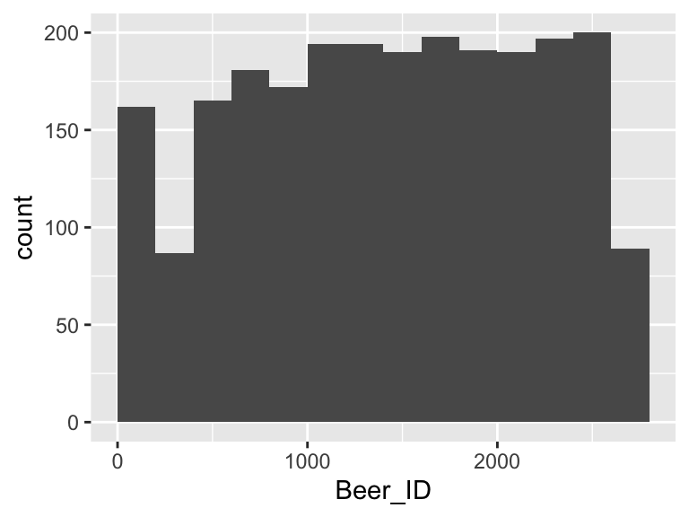

## ABV

| Feature | Result |
| --- | --- |
| Variable type | numeric |
| Number of missing obs. | 62 (2.57 %) |
| Number of unique values | 74 |
| Median | 0.06 |
| 1st and 3rd quartiles | 0.05; 0.07 |
| Min. and max. | 0; 0.13 |

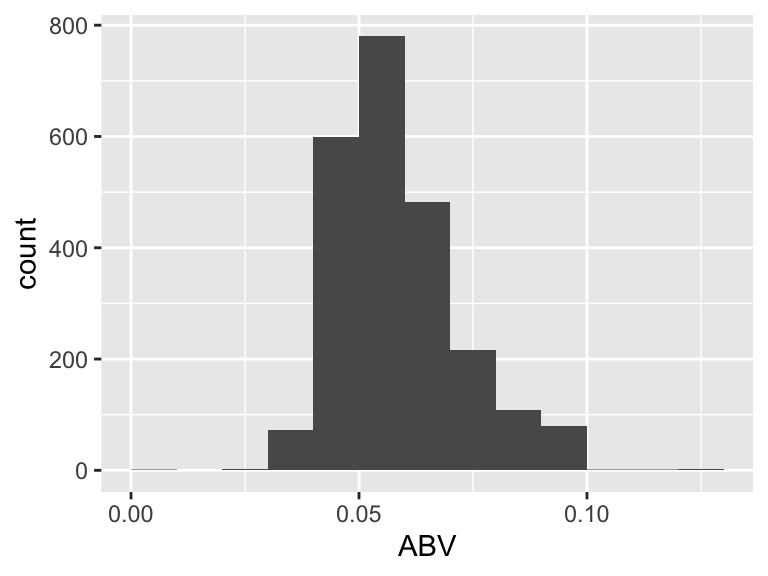

## IBU

| Feature | Result |
| --- | --- |
| Variable type | numeric |
| Number of missing obs. | 1005 (41.7 %) |
| Number of unique values | 107 |
| Median | 35 |
| 1st and 3rd quartiles | 21; 64 |
| Min. and max. | 4; 138 |

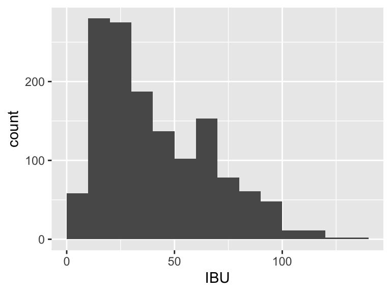

## Brewery_id

| Feature | Result |
| --- | --- |
| Variable type | numeric |
| Number of missing obs. | 0 (0 %) |
| Number of unique values | 558 |
| Median | 206 |
| 1st and 3rd quartiles | 94; 367 |
| Min. and max. | 1; 558 |

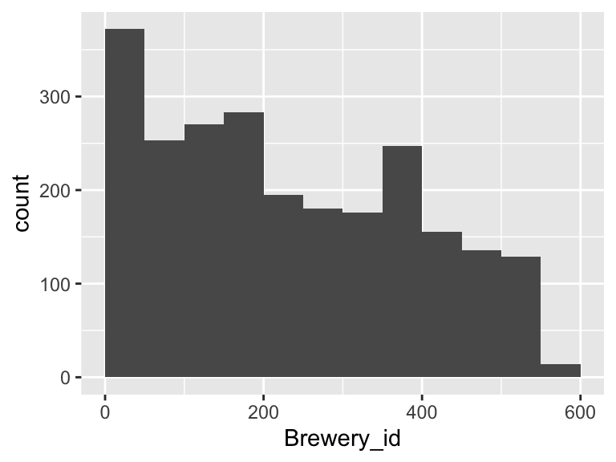

## Style

| Feature | Result |
| --- | --- |
| Variable type | character |
| Number of missing obs. | 5 (0.21 %) |
| Number of unique values | 99 |
| Mode | “American IPA” |

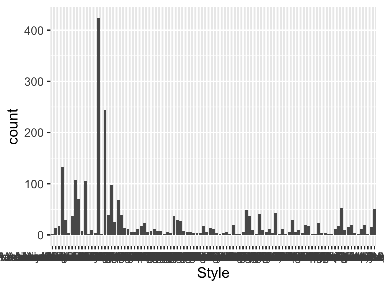

- Observed factor levels: "Abbey Single Ale", "Altbier", "American Adjunct Lager", "American Amber / Red Ale", "American Amber / Red Lager", "American Barleywine", "American Black Ale", "American Blonde Ale", "American Brown Ale", "American Dark Wheat Ale", "American Double / Imperial IPA", "American Double / Imperial Pilsner", "American Double / Imperial Stout", "American India Pale Lager", "American IPA", "American Malt Liquor", "American Pale Ale (APA)", "American Pale Lager", "American Pale Wheat Ale", "American Pilsner", "American Porter", "American Stout", "American Strong Ale", "American White IPA", "American Wild Ale", "Baltic Porter", "Belgian Dark Ale", "Belgian IPA", "Belgian Pale Ale", "Belgian Strong Dark Ale", "Belgian Strong Pale Ale", "Berliner Weissbier", "Bière de Garde", "Bock", "Braggot", "California Common / Steam Beer", "Chile Beer", "Cider", "Cream Ale", "Czech Pilsener", "Doppelbock", "Dortmunder / Export Lager", "Dubbel", "Dunkelweizen", "English Barleywine", "English Bitter", "English Brown Ale", "English Dark Mild Ale", "English India Pale Ale (IPA)", "English Pale Ale", "English Pale Mild Ale", "English Stout", "English Strong Ale", "Euro Dark Lager", "Euro Pale Lager", "Extra Special / Strong Bitter (ESB)", "Flanders Oud Bruin", "Flanders Red Ale", "Foreign / Export Stout", "Fruit / Vegetable Beer", "German Pilsener", "Gose", "Grisette", "Hefeweizen", "Herbed / Spiced Beer", "Irish Dry Stout", "Irish Red Ale", "Keller Bier / Zwickel Bier", "Kölsch", "Kristalweizen", "Light Lager", "Low Alcohol Beer", "Maibock / Helles Bock", "Märzen / Oktoberfest", "Mead", "Milk / Sweet Stout", "Munich Dunkel Lager", "Munich Helles Lager", "Oatmeal Stout", "Old Ale", "Other", "Pumpkin Ale", "Quadrupel (Quad)", "Radler", "Rauchbier", "Roggenbier", "Russian Imperial Stout", "Rye Beer", "Saison / Farmhouse Ale", "Schwarzbier", "Scotch Ale / Wee Heavy", "Scottish Ale", "Shandy", "Smoked Beer", "Tripel", "Vienna Lager", "Wheat Ale", "Winter Warmer", "Witbier".

## Ounces

| Feature | Result |
| --- | --- |
| Variable type | numeric |
| Number of missing obs. | 0 (0 %) |
| Number of unique values | 7 |
| Median | 12 |
| 1st and 3rd quartiles | 12; 16 |
| Min. and max. | 8.4; 32 |

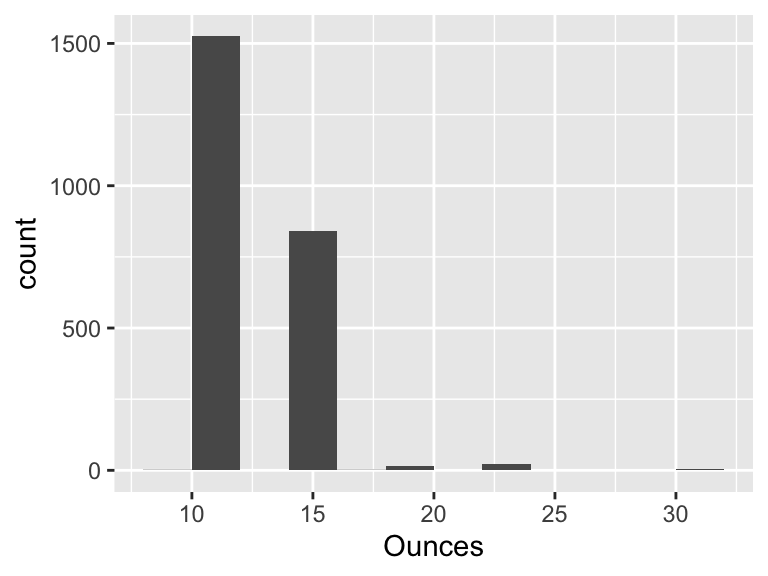

Report generation information:

- Created by: Ricco Ferraro (username: `riccoferraro`).
- Report creation time: Mon Mar 08 2021 00:14:08
- Report was run from directory: `/Users/riccoferraro/Documents/SMU/DDS/MSDS_6306_Doing-Data-Science/dds_case_study_1`
- dataMaid v1.4.0 [Pkg: 2019-12-10 from CRAN (R 4.0.2)]
- R version 4.0.2 (2020-06-22).
- Platform: x86_64-apple-darwin17.0 (64-bit)(macOS 10.16).
- Function call: `dataMaid::makeDataReport(data = beer, mode = c("summarize", "visualize", "check"), smartNum = FALSE, file = "codebook_beer.Rmd", checks = list( character = "showAllFactorLevels", factor = "showAllFactorLevels", labelled = "showAllFactorLevels", haven_labelled = "showAllFactorLevels", numeric = NULL, integer = NULL, logical = NULL, Date = NULL), listChecks = FALSE, maxProbVals = Inf, codebook = TRUE, reportTitle = "Codebook for beer")`